# Analysis of NOAA Storm Database

Nikhila Arkalgud

February 22, 2015

Synopsis:

Data Processing:

Download the Storm Data from https://d396qusza40orc.cloudfront.net/repdata%2Fdata%2FStormData.csv.bz2 Unzip the file and read the csv file into R.

```r
stdata <- read.csv(bzfile("repdata-data-StormData.csv.bz2"))
```

We will check the dimentionality of this dataset

```r
dim(stdata)
```

```
## [1] 902297     37
```

```r
head(stdata)
```

```
##   STATE__           BGN_DATE BGN_TIME TIME_ZONE COUNTY COUNTYNAME STATE
## 1       1  4/18/1950 0:00:00     0130       CST     97     MOBILE    AL
## 2       1  4/18/1950 0:00:00     0145       CST      3    BALDWIN    AL
## 3       1  2/20/1951 0:00:00     1600       CST     57    FAYETTE    AL
## 4       1   6/8/1951 0:00:00     0900       CST     89    MADISON    AL
## 5       1 11/15/1951 0:00:00     1500       CST     43    CULLMAN    AL
## 6       1 11/15/1951 0:00:00     2000       CST     77 LAUDERDALE    AL
##    EVTYPE BGN_RANGE BGN_AZI BGN_LOCATI END_DATE END_TIME COUNTY_END
## 1 TORNADO         0                                               0
## 2 TORNADO         0                                               0
## 3 TORNADO         0                                               0
## 4 TORNADO         0                                               0
## 5 TORNADO         0                                               0
## 6 TORNADO         0                                               0
##   COUNTYENDN END_RANGE END_AZI END_LOCATI LENGTH WIDTH F MAG FATALITIES
```

[output cut: 20 more lines]

We will find the total fatalities and injuries resulted from each disaster event type which is represented in this dataset under EVTYPE

```r
# aggregate the total fatalities for each evtype
ph_fatality <- aggregate(stdata$FATALITIES, by=list(stdata$EVTYPE), FUN=sum)
names(ph_fatality) <- make.names(c("evtype","fatality"))

# aggregate the total injuries for each evtype
ph_injury <- aggregate(stdata$INJURIES, by=list(stdata$EVTYPE), FUN=sum)
names(ph_injury) <- make.names(c("evtype","injury"))
```

We will now process these subsets to find the cummulative sum and cummulative fraction for both fatalities and injuries. This will help us isolate the events that cummulatively contribute to 95% of the total fatality and the events that cummulatively contribute to 95% of the total injuries.

```r
# we will calculate the cummulative sum and find the cummulative fraction for each event
# this will help us identify the events that
# cummulatively contribute to 95% of the total fatality

# sort the ph_fatality in desending order
phfo <- ph_fatality[order(-ph_fatality[,2]),]

#append a col cufrac to phfo
phfo$cufrac <- cumsum(phfo$fatality)/sum(phfo$fatality)
```

```r
# we will calculate the cummulative sum and find the cummulative fraction for each event
# this will help us identify the events that
# cummulatively contribute to 95% of the total injuries

# sort the ph_injury in desending order
phio <- ph_injury[order(-ph_injury[,2]),]

#append a col cufrac to phio
phio$cufrac <- cumsum(phio$injury)/sum(phio$injury)
```

We will also extract the total property damage and the crop damage resulted from each disaster event type. Economic disaster for each event type can be measured using PROPDMG and PROPDMGEXP columns. The PROPDMGEXP column procides the magnitude, with ‘K’ representing thousand dollars, ‘M’ for millon dollars and ‘B’ for billion dollars. Similarly CROPDMG and CROPDMGEXP are used for estimating the crop damage. We will add the property damages and crop damages to obtain the raw dollar amount of economic damage for each event type.

```r
#append a column to replace 'K', 'M' and 'B' provided under CROPDMGEXP
#with 1000,1000000,1000000000, empty rows are replaced by 1
#then multiply this value with the value provided under CROPDMG

# start by making all rows 1
stdata$cropDamage <- 1

#extract the K, M and B logical indices
kindices <- stdata$CROPDMGEXP == 'K'
mindices <- stdata$CROPDMGEXP == 'M'
bindices <- stdata$CROPDMGEXP == 'B'

# assign 1000, 1000000 and 1000000000 to replace the K, M and B
stdata$cropDamage[kindices] <- 1000
stdata$cropDamage[mindices] <- 1000000
stdata$crop[bindices] <- 1000000000

#multiply with CROPDMG column to get the actual economic damage for this event
stdata$cropDamage <- stdata$CROPDMG * stdata$cropDamage
```

```r
#append a column to replace 'K', 'M' and 'B' provided under PROPDMGEXP
#with 1000,1000000,1000000000, empty rows are replaced by 1
#then multiply this value with the value provided under PROPDMG

# start by making all rows 1
stdata$economicDamage <- 1

#extract the K, M and B logical indices
kindices <- stdata$PROPDMGEXP == 'K'
mindices <- stdata$PROPDMGEXP == 'M'
bindices <- stdata$PROPDMGEXP == 'B'

# assign 1000, 1000000 and 1000000000 to replace the K, M and B
stdata$economicDamage[kindices] <- 1000
stdata$economicDamage[mindices] <- 1000000
stdata$economicDamage[bindices] <- 1000000000

#multiply with PROPDMG column to get the actual economic damage for this event
#add the corresponding crop damage to this value
stdata$economicDamage <- (stdata$PROPDMG * stdata$economicDamage) + stdata$cropDamage

#aggregate the economic damage by each event type
ed <- aggregate(stdata$economicDamage, by=list(stdata$EVTYPE), FUN=sum)
names(ed) <- make.names(c("evtype","economicDamage"))

# sort the data by economicDamage in desending order
ed_ordered <- ed[order(-ed[,2]),]
```

```r
# we will calculate the cummulative sum and find the cummulative fraction for each event
# this will help us identify the events that
# cummulatively contribute to 95% of the total economic damage

#append a col cufrac to ed_ordered
ed_ordered$cufrac <- cumsum(ed_ordered$economicDamage)/sum(ed_ordered$economicDamage)
```

Results:

We will examine two keys effects that result due to the occurance of these events:

1. How does this affect the population health?
2. What are the economic consequences?

For each of these cases, examining the events that contribute to the 95% of the cummulative damage is a good measure to identify the most damaging events. We will display these events and their respective values. We will then plot the top 10 events for each of these categories.

1. How does this affect the population health?

We will analyze the number of fatalities and injuries that have occurred due to these events. This will help us analyze the effect these events have on the population health.

We will look at the events that contribute to 95% of the cummulative fatalites that results from these events.

```r
# display the events that contribute to 90% of the total fatality
top95_f <- phfo[phfo$cufrac < 0.95,]

#total number of events
nrow(phfo)
```

```
## [1] 985
```

```r
#total number of events contributing to the 95% of total fatality
nrow(top95_f)
```

```
## [1] 32
```

```r
#list of these events contributing to the 95% of total fatality
top95_f
```

```
##                      evtype fatality    cufrac
## 834                 TORNADO     5633 0.3719379
## 130          EXCESSIVE HEAT     1903 0.4975900
## 153             FLASH FLOOD      978 0.5621657
## 275                    HEAT      937 0.6240343
## 464               LIGHTNING      816 0.6779135
## 856               TSTM WIND      504 0.7111918
## 170                   FLOOD      470 0.7422252
## 585             RIP CURRENT      368 0.7665236
## 359               HIGH WIND      248 0.7828986
## 19                AVALANCHE      224 0.7976890
## 972            WINTER STORM      206 0.8112909
## 586            RIP CURRENTS      204 0.8247606
## 278               HEAT WAVE      172 0.8361175
## 140            EXTREME COLD      160 0.8466821
```

[output cut: 18 more lines]

There are 32 events out of the total 985 events that contribute to 95% of the total number of fatalities.

The below bar chart shows top 10 events that contribute to the highest fatality

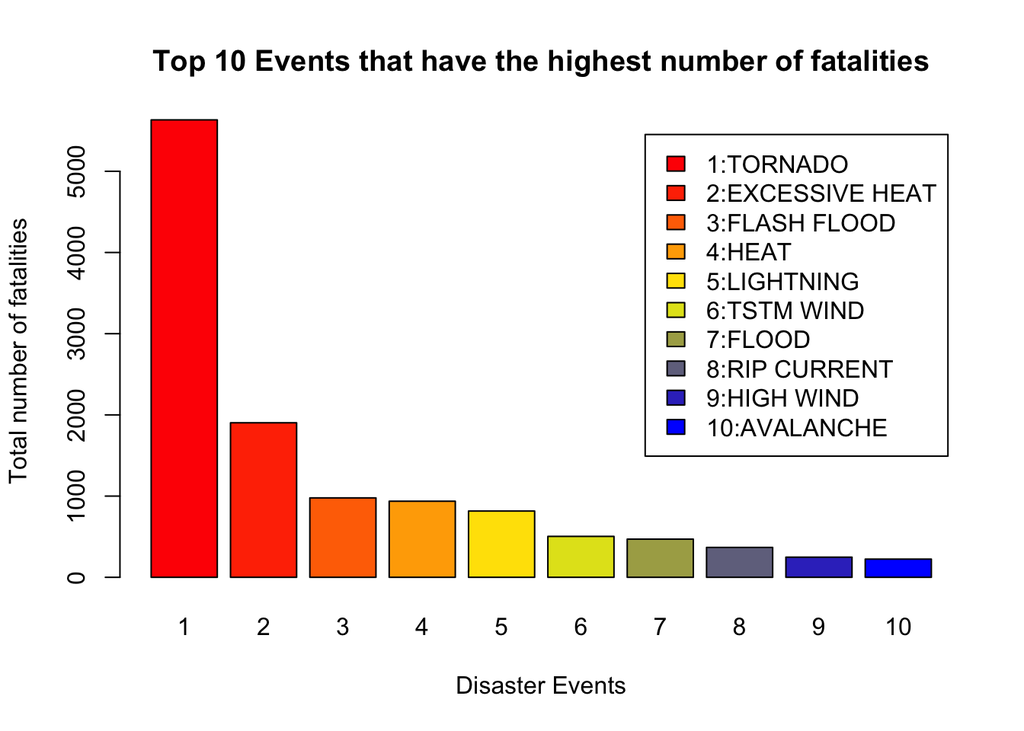

```r
events <- top95_f$evtype[1:10]
labels <- paste(seq(1:10),events,sep=":")
ramp <- colorRamp(c("red","yellow","blue"))
barplot(top95_f$fatality[1:10], main = "Top 10 Events that have the highest number of fatalities", xlab = "Disaster Events", ylab = "Total number of fatalities", names.arg = seq(1:10), legend = labels, col = rgb(ramp(seq(0,1,length=10)),max=255))
```

From the barchart and also the table above we see that tornado has the highest number of fatalities.

```r
top95_f[1,1:2]
```

```
##      evtype fatality
## 834 TORNADO     5633
```

Now we will examine the injuries that have resulted due to these disaster events.

We will look at the events that contribute to 95% of the cummulative injuries that results from these events.

```r
# display the events that contribute to 95% of the total injuries
top95_i <- phio[phio$cufrac < 0.95,]

#total number of events
nrow(phio)
```

```
## [1] 985
```

```r
#total number of events contributing to the 95% of total injuries
nrow(top95_i)
```

```
## [1] 17
```

```r
#list of these events contributing to the 95% of total injuries
top95_i
```

```
##                 evtype injury    cufrac
## 834            TORNADO  91346 0.6500199
## 856          TSTM WIND   6957 0.6995261
## 170              FLOOD   6789 0.7478367
## 130     EXCESSIVE HEAT   6525 0.7942688
## 464          LIGHTNING   5230 0.8314855
## 275               HEAT   2100 0.8464292
## 427          ICE STORM   1975 0.8604833
## 153        FLASH FLOOD   1777 0.8731285
## 760  THUNDERSTORM WIND   1488 0.8837171
## 244               HAIL   1361 0.8934020
## 972       WINTER STORM   1321 0.9028023
## 411  HURRICANE/TYPHOON   1275 0.9118752
## 359          HIGH WIND   1137 0.9199661
## 310         HEAVY SNOW   1021 0.9272316
## 957           WILDFIRE    911 0.9337143
## 786 THUNDERSTORM WINDS    908 0.9401756
## 30            BLIZZARD    805 0.9459040
```

There are 17 events out of the total 985 events that contribute to 95% of the total number of injuries.

The below bar chart shows top 10 events that contribute to the highest number of injuries.

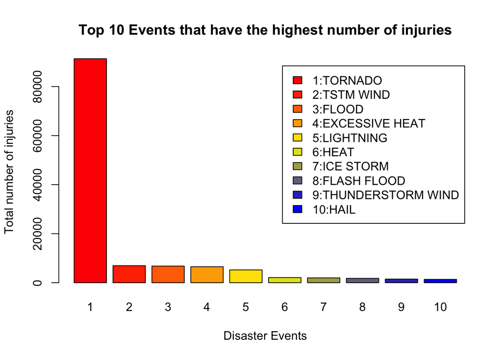

```r
events <- top95_i$evtype[1:10]
labels <- paste(seq(1:10),events,sep=":")
ramp <- colorRamp(c("red","yellow","blue"))
barplot(top95_i$injury[1:10], main = "Top 10 Events that have the highest number of injuries", xlab = "Disaster Events", ylab = "Total number of injuries", names.arg = seq(1:10), legend = labels, col = rgb(ramp(seq(0,1,length=10)),max=255))
```

From both the barchart and the table above we see that tornados also have also resulted in the highest number of injuries.

```r
top95_i[1,1:2]
```

```
##      evtype injury
## 834 TORNADO  91346
```

2. What are the economic consequences?

We will now examine the events that have the greatest economic consequences. We will look at the property damage and the crop damage associated to each of these events. We will combine these two damages to obtain the economic damage for each event.

We will look at the events that contribute to 95% of the cummulative economic damage that results from these events.

```r
# display the events that contribute to 95% of the total economic damage
top95_e <- ed_ordered[ed_ordered$cufrac < 0.95,]

#total number of events
nrow(ed_ordered)
```

```
## [1] 985
```

```r
#total number of events contributing to the 95% of total economic damage
nrow(top95_e)
```

```
## [1] 18
```

```r
#list of these events contributing to the 95% of total economic damage
top95_e
```

```
##                evtype economicDamage    cufrac
## 170             FLOOD   150319678257 0.3248305
## 411 HURRICANE/TYPHOON    70403712802 0.4769680
## 834           TORNADO    57340614060 0.6008771
## 670       STORM SURGE    43323541000 0.6944963
## 244              HAIL    18752904943 0.7350200
## 153       FLASH FLOOD    17562129167 0.7729706
## 402         HURRICANE    14610229010 0.8045423
## 95            DROUGHT    13518672002 0.8337552
## 848    TROPICAL STORM     8382236550 0.8518686
## 972      WINTER STORM     6715441251 0.8663802
## 359         HIGH WIND     5908617595 0.8791484
## 590       RIVER FLOOD     5148404505 0.8902737
## 957          WILDFIRE     5060586800 0.9012093
## 856         TSTM WIND     5038935845 0.9120981
## 671  STORM SURGE/TIDE     4642038000 0.9221292
## 427         ICE STORM     3967041365 0.9307017
## 760 THUNDERSTORM WIND     3897964334 0.9391249
## 408    HURRICANE OPAL     3161846030 0.9459575
```

There are 18 events out of the total 985 events that contribute to 95% of the total economic damage.

The below bar chart shows top 10 events that contribute to the highest economic damage

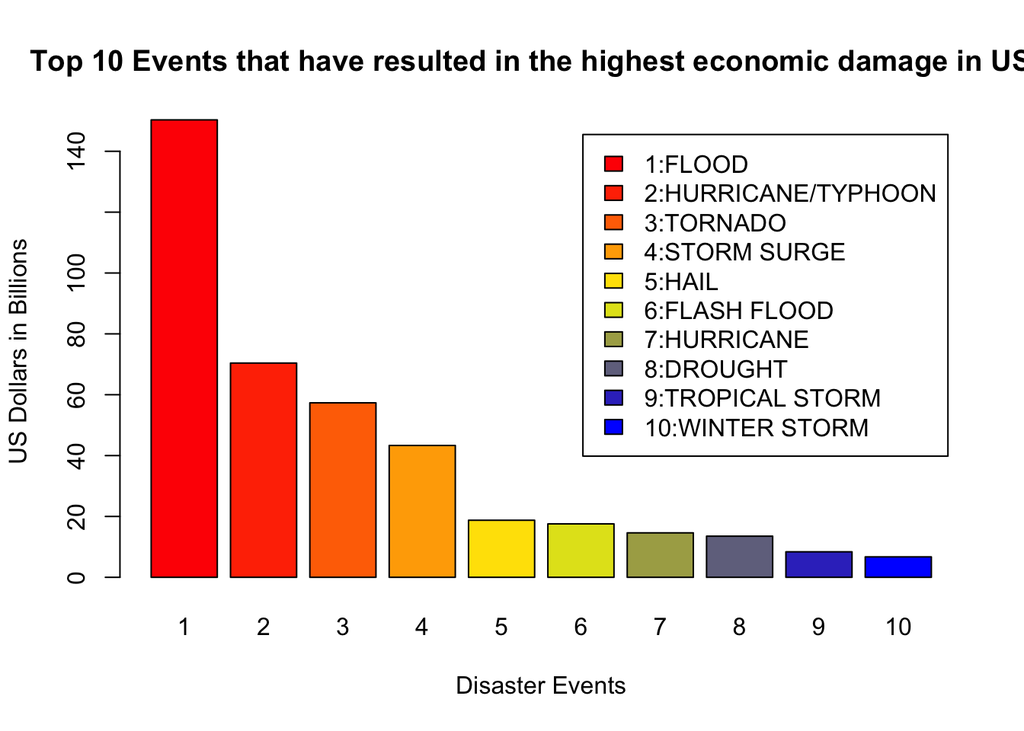

```r
events <- top95_e$evtype[1:10]

ed_in_billions <- top95_e$economicDamage[1:10]/1000000000

labels <- paste(seq(1:10),events,sep=":")

ramp <- colorRamp(c("red","yellow","blue"))

barplot(ed_in_billions, main = "Top 10 Events that have resulted in the highest economic damage in USD", xlab = "Disaster Events", ylab = "US Dollars in Billions", names.arg = seq(1:10), legend = labels, col = rgb(ramp(seq(0,1,length=10)),max=255))
```

From the barchart and the table above we see that Floods have resulted in the maximum economic damage.

```r
top95_e[1,1:2]
```

```
##     evtype economicDamage
## 170  FLOOD   150319678257
```

Floods have resulted in the highest economic damage, which is a combined result of crop and property damages and resulted in high economic consequences, the US Dollars reported are more than twice the second highest event(hurricane).

Interestingly, although floods have high economic consequences, they seem to have less effect on population health. Tornados in contrast are the highest in population health and have significant effects on economy as well, tornadoes are the third highest contributing event to economic damages.